# Financial Inclusion in Uganda, 2011 to 2024

Mobile money, the gender gap, and who is being left behind

Author

Peter Kugonza

Published

October 9, 2026

## Summary

Account ownership among Ugandan adults rose from **20.5% in 2011 to 72.8% in 2024**. Mobile money drove most of this growth: **67.7% of adults** had a mobile money account in 2024. However, access is not equal. Women, rural adults and people with less education are still less likely to have an account.

## 1. Account ownership has more than tripled

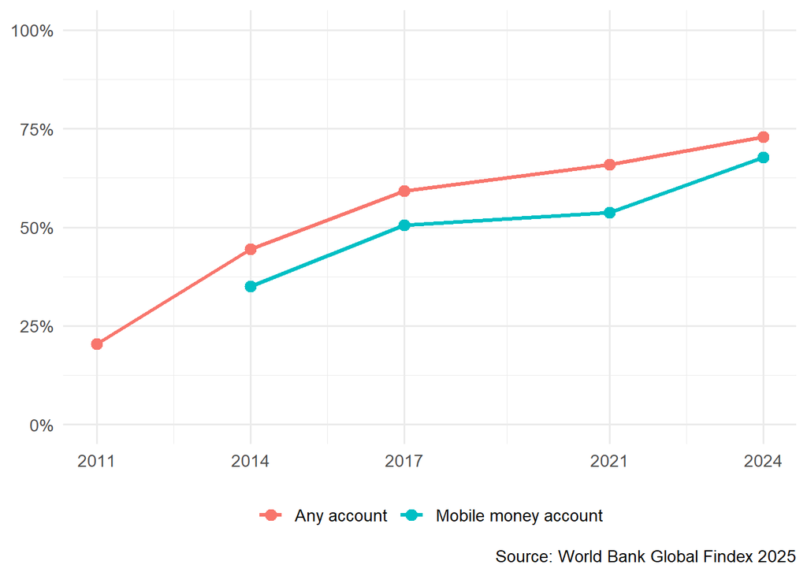

Mobile money was first measured in 2014, when 35.1% of adults had an account. By 2024 that had almost doubled.

## 2. The gender gap

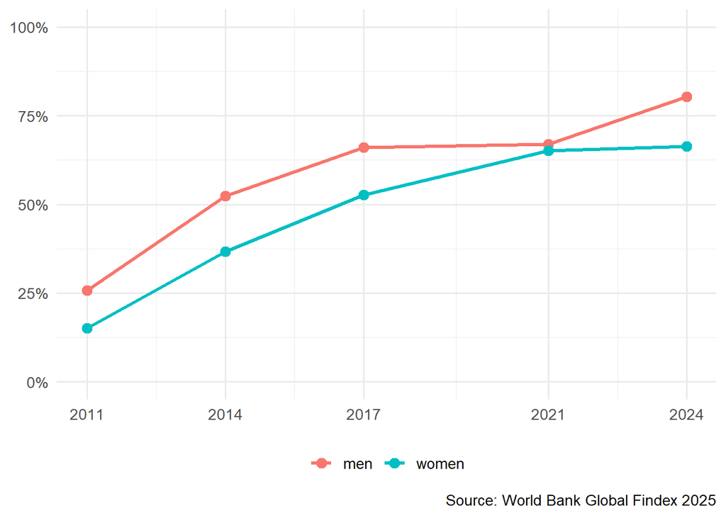

| Year | Men | Women | Gap (points) |
| --- | --- | --- | --- |
| 2011 | 25.8% | 15.1% | 10.7 |
| 2014 | 52.4% | 36.6% | 15.7 |
| 2017 | 66.1% | 52.7% | 13.4 |
| 2021 | 66.9% | 65.1% | 1.8 |
| 2024 | 80.3% | 66.4% | 13.9 |

The gap nearly closed in 2021 (1.8 points) but widened again to 13.9 points in 2024.

## 3. Who is being left behind? (2024)

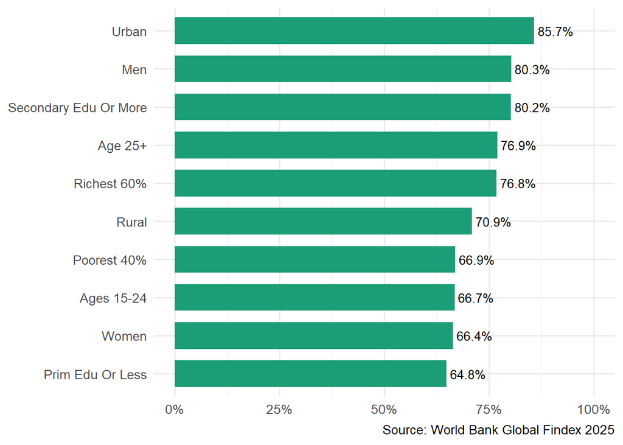

In 2024, urban adults (85.7%) were more likely to have an account than rural adults (70.9%), and adults with secondary education or more (80.2%) were more likely than those with primary education or less (64.8%).

## Recommendations

- **Target women directly.** The gap widened again after 2021, so programmes should include women-focused agent networks, financial literacy and products.
- **Reach rural areas.** A 15-point rural gap suggests agent coverage and connectivity still matter.
- **Pair access with education.** Lower account ownership among adults with less schooling points to a need for simple products and training.

## Data and limits

Source: World Bank Global Findex Database 2025, country-level data for Uganda. The data are survey estimates for groups of adults, not individual records, so this report describes patterns but cannot explain their causes. Location data are available for 2024 only.